# Detecting people's emotions with facial coverings in images using Amazon Rekognition

Wearing face masks is one of the essential means to prevent the transmission of certain respiratory diseases such as COVID-19. Although acceptance of such masks is increasing in the Western hemisphere, many people feel that social interaction is affected by wearing a mask. From our sociology class, we have read an article titled “[Wearing Face Masks Strongly Confuses Counterparts in Reading Emotions.](https://doi.org/10.3389/fpsyg.2020.566886)” written by Claus-Christian Carbon, and we learned that the existence of a mask affects emotional reading, as evidenced by reduced accuracy and trust in one's own judgment of the revealed emotions. We often have a hard time deciphering people' feelings through their limited facial expression wearing masks, as seen in the article and in our daily lives. However, we want to learn whether the capability of machine (Amazon Rekognition) to read emotions will be affected with facial coverings. We will also investigate to what extend the capability will be affected.

## Amazon Rekogintion Face Detection Overview

A face detection system is meant to answer that question. Any face visible in a still picture or video frame is detected by a face detection system, which identifies its existence, position, scale, and (potentially) orientation. This technology is intended to identify the presence of people regardless of their gender, age, or facial hair.

In the form of a probability or confidence score, the face detection system can offer an indication of the prediction's confidence level. For example, it may predict that a smiling face with a confidence score of 90% of "appearing to be happy", whereas another calm face image with a confidence level of 20% of "appearing to be happy". A happy face should be more likely to be found in the location with the highest confidence level.

## Architecture Diagram and Explanation

We collect the images by taking photos(outside resources), and upload it into the AWS S3 bucket as objects. Then we can set up a notebook with AWS SageMaker. We set the IAM Role to grant permissions to applications running on our instances that need to use a bucket in Amazon S3. The data we have now in S3 generates an event notification. This initiates function that sends the details of the uploaded image to Amazon Rekognition for tagging. Results from Amazon Rekognition could be further processed by the function and do the facial analysis, which includes the emotional output we want. Finally, we can extract the information we need into S3 bucket.

[figure not shown]

## Dataset Creation

Our data came from pictures taken by our 4 group members. Each of us contributed 12 pictures, so we have a total of 48 pictures. 12 pictures include 3 pictures with 4 emotions (angry, surprised, happy, sad) and no facial coverings, with masks, and with sunglasses. We created two DataFrames to test our hypothesis. For one DataFrame, we tried to test the relationship between confidence score and emotions. For the other DataFrame, we tried to test the relationship between confidence score and facial coverings. The details of the DataFrames will be explained in more detail in the sections below.

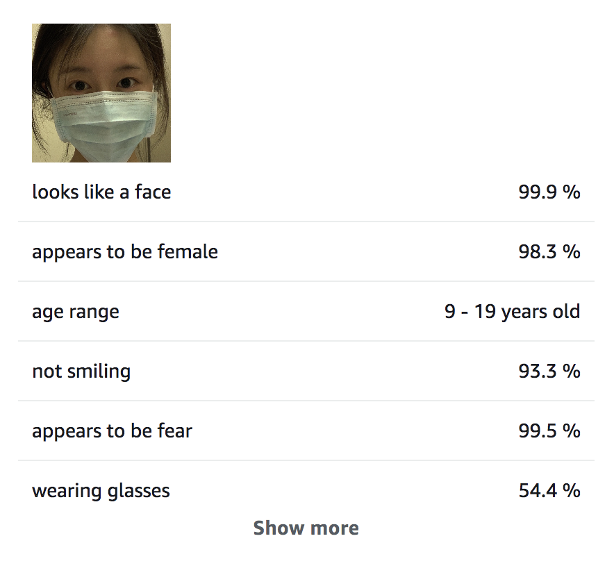

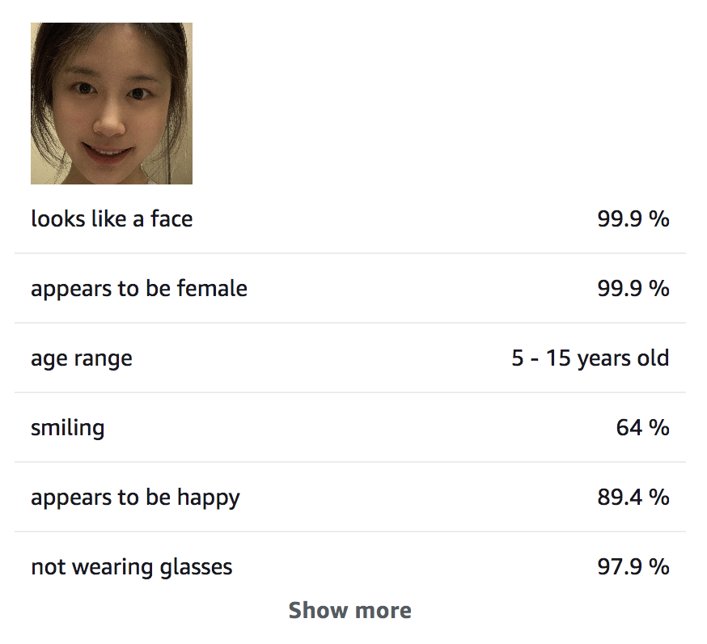

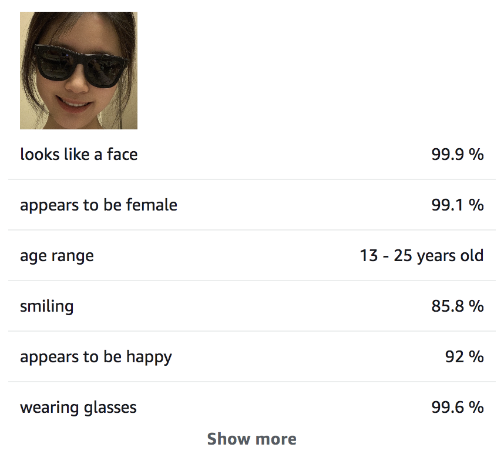

## Facial Coverings' Impacts on Amazon Rekognition's Emotion Reading Accuracy

To address our research question, we first investigate whether wearing facial coverings (masks or glasses) would affect the accuracy of Amazon Rekognition on reading people's emotions (angry, happy, sad, and surprised). In this case, the independent variable would be wearing a mask or a pair of sunglasses or nothing, and the dependent variable would be the confidence scores. We calculate the confidence scores for each photo. Then we regard the faces without facial coverings as the "original" ones and compare the differences of confidence scores between the ones with facial masks, the ones with sunglasses, and the "original" ones.

Since the four emotions are all "extreme" ones which means if a person wants to show their happiness, sadness, anger, or surprise, they should intentionally express it. In this way, we assume that if a person is detected to be "happy", and they put on a mask or a pair of sunglasses, then the overall confidence scores of angry, happy, sad, or surprised should decrease. Based on the assumption, we calculate the sum of confidence scores for four emotions for each case. Then we intend to test whether there exist statistically significant differences between the confidence scores for naked faces and faces with coverings.

We first assume that the distribution of the confidence scores will be a normal distribution, and we decide to use t-testing because t-test is a type of inferential statistic used to determine if there is a significant difference between the means of two groups, which may be related in certain features. It is mostly used when the data sets, like the data set recorded as the outcome from flipping a coin 100 times, would follow a normal distribution and may have unknown variances. A t-test is used as a hypothesis testing tool, which allows testing of an assumption applicable to a population. We have also decided to use 95% as our confidence interval. 95% confidence interval defines a range of values that we can be 95% certain contains the population mean.

### Methods

We first create a dataframe with 4 emotions'(happy, sad, surprised, angry) confidence scores and three binary varibales (Origin_Y, Mask_Y, Sunglasses_Y).

To indicate whether the person in the image is wearing facial coverings, we assign binary score (0 indicates NO, 1 indicates YES) to demonstrate the features. For example, if a person is wearing a mask, then Origin_Y is equal to 0, Mask_Y is equal to 1, and Sunglasses_Y is equal to 0.

*One part of the result*

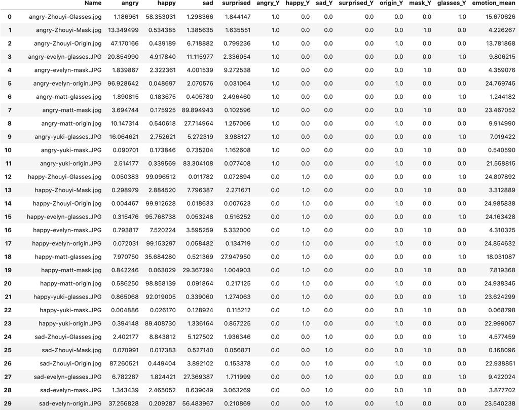

Write the function to get the mean and standard value for each picture, with the variable as whether or not wearing the mask or sunglasses.

```
emotion_mask = 0
emotion_origin = 0
emotion_glasses = 0
for l in range(0,48):
    if df.origin_Y[l] ==1:
        emotion_origin = emotion_origin + df.emotion_mean[l]
    if df.mask_Y[l] ==1:
        emotion_mask = emotion_mask + df.emotion_mean[l]
    if df.glasses_Y[l] ==1:
        emotion_glasses = emotion_glasses + df.emotion_mean[l]
emotion_mask_mean = emotion_mask/16
emotion_origin_mean = emotion_origin/16
emotion_glasses_mean = emotion_glasses/16
std_mask_sum = 0
std_ori_sum =0
std_gla_sum =0
for k in range(0,48):
    if df.origin_Y[k] ==1:
        std_ori_sum=std_ori_sum+(emotion_origin_mean-df.emotion_mean[k])*(emotion_origin_mean-df.emotion_mean[k])
    if df.mask_Y[k] ==1:
        std_mask_sum=std_mask_sum+(emotion_mask_mean-df.emotion_mean[k])*(emotion_mask_mean-df.emotion_mean[k])
    if df.glasses_Y[k] ==1:
        std_gla_sum=std_gla_sum+(emotion_glasses_mean-df.emotion_mean[k])*(emotion_glasses_mean-df.emotion_mean[k])
std_mask=np.sqrt(std_mask_sum/16)
std_ori=np.sqrt(std_ori_sum/16)
std_gla=np.sqrt(std_gla_sum/16)
```

We then do the t-test to compare the difference of results between with/without glasses. The null hypothesis here is that there is no difference for the output.

**H1_0: the machine shows no difference in detecting the face with no coverings and the face with sunglasses.**

```
def t_ori_gla():
    difference = emotion_origin_mean - emotion_glasses_mean
    t_stat = difference/np.sqrt(std_ori*std_ori/16+std_gla*std_gla/16)
    if t_stat <2.05 and t_stat>-2.04:
        print ('It fails to reject the null hypothesis so that Rokognition does not present a significant difference for reading emotions with the target sunglasses on or not ')
        print(t_stat)
    else:
        print( 'It rejects the null hypothesis so that Rokognition does present a significant difference for reading emotions with the target sunglasses on or not ')
        print(t_stat)
```

```
t_ori_gla()
```

t-statistics: 2.954605025904006

It rejects the null hypothesis so that Rokognition does present a significant difference for reading emotions with the target sunglasses on or not.

Since the conclusion is rejecting the null hypothesis, the glasses do have impact on the result.

We then do the t-test to compare the difference of results between with/without masks. The null hypothesis here is that there is no difference for the output.

**H2_0: the machine shows no difference in detecting the face with no coverings and the face with mask.**

```
def t_ori_mask():
    difference = emotion_origin_mean - emotion_mask_mean
    t_stat = difference/np.sqrt(std_ori*std_ori/16+std_gla*std_mask/16)
    if t_stat <2.05 and t_stat>-2.04:
        print ('It fails to reject the null hypothesis so that Rokognition does not present a significant difference for reading emotions with the mask on or not ')
        print(t_stat)
    else:
        print( 'It rejects the null hypothesis so that Rokognition does present a significant difference for reading emotions with the mask on or not ')
        print(t_stat)
```

```
t_ori_mask()
```

t-statistics:5.941801345057431

It rejects the null hypothesis so that Rokognition does present a significant difference for reading emotions with the mask on or not.

Since the conclusion is rejecting the null hypothesis, the masks do have impact on the result.

## Emotion Types' Impacts on Amazon Rekognition's Emotion Reading Accuracy

### Methods

We write the function to do the t-test for each emotion type. If we reject the null hypothesis, which means the Rekognition will represent a significant difference for that specific facial expression, we can explore and compare them more. Otherwise, we say that the Rekognition is not able to detect this emotion from others, and thus rule out the type.

**H1_0: the machine shows no difference in detecting the angry emotion and the rest of the emotion.**

```
def t_test_angry(df):
    difference_angry = df[df.angry_Y==1].angry.mean()-df[df.angry_Y==0].angry.mean()
    t_stat = difference_angry/np.sqrt(df.angry.std()*df.angry.std()*(1/12+1/36))
    if t_stat <2.012 and t_stat>-2.012:
        print ('It fails to reject the null hypothesis so that Rokognition does not present a significant difference for our angry facial expression ')
        print(t_stat)
    else:
        print( 'It rejects the null hypothesis so that Rokognition does present a significant difference for our angry facial expression ')
        print(t_stat)
```

```
t_test_angry(df)
```

t-statistics: 1.47144181000293

It fails to reject the null hypothesis so that Rokognition does not present a significant difference for our angry facial expression.

**H2_0: the machine shows no difference in detecting the happy emotion and the rest of the emotion.**

```
def t_test_happy(df):
    difference_happy = df[df.happy_Y==1].happy.mean()-df[df.happy_Y==0].happy.mean()
    t_stat = difference_happy/np.sqrt(df.happy.std()*df.happy.std()*(1/12+1/36))
    if t_stat <2.012 and t_stat>-2.012:
        print ('It fails to reject the null hypothesis so that Rokognition does not present a significant difference for our happy facial expression ')
        print(t_stat)
    else:
        print( 'It rejects the null hypothesis so that Rokognition does present a significant difference for our happy facial expression ')
        print(t_stat)
```

```
t_test_happy(df)
```

t-statistics: 4.96784444542863

It rejects the null hypothesis so that Rokognition does present a significant difference for our happy facial expression.

**H3_0: the machine shows no difference in detecting the surprised emotion and the rest of the emotion.**

```
def t_test_surprised(df):
    difference_sur = df[df.surprised_Y==1].surprised.mean()-df[df.surprised_Y==0].surprised.mean()
    t_stat = difference_sur/np.sqrt(df.surprised.std()*df.surprised.std()*(1/12+1/36))
    if t_stat <2.012 and t_stat>-2.012:
        print ('It fails to reject the null hypothesis so that Rokognition does not present a significant difference for our surprised facial expression ')
        print(t_stat)
    else:
        print( 'It rejects the null hypothesis so that Rokognition does present a significant difference for our surprised facial expression ')
        print(t_stat)
```

```
t_test_surprised(df)
```

t-statistics: 5.086714770280857

It rejects the null hypothesis so that Rokognition does present a significant difference for our surprised facial expression.

**H4_0: the machine shows no difference in detecting the sad emotion and the rest of the emotion.**

```
def t_test_sad(df):
    difference_sad = df[df.sad_Y==1].sad.mean()-df[df.sad_Y==0].sad.mean()
    t_stat = difference_sad/np.sqrt(df.sad.std()*df.sad.std()*(1/12+1/36))
    if t_stat <2.012 and t_stat>-2.012:
        print ('It fails to reject the null hypothesis so that Rokognition does not present a significant difference for our sad facial expression ')
        print(t_stat)
    else:
        print( 'It rejects the null hypothesis so that Rokognition does present a significant difference for our sad facial expression ')
        print(t_stat)
```

```
t_test_sad(df)
```

t-statistics: 2.0771953873131195

It rejects the null hypothesis so that Rokognition does present a significant difference for our sad facial expression.

The outcome is that except for angry, the other three emotions can be detected since they all rejects the null hypothesis. We then do the t-test to compare the accuracy among these three types.

First we compare "happy" with "sad" with the null hypothesis:

**H5_0: the machine shows no difference in detecting the sad emotion and the happy emotion**

```
def t_test_happy_sad(df):
    difference_hs = df[df.happy_Y==1].happy.mean()-df[df.sad_Y==1].sad.mean()
    t_stat = difference_hs/np.sqrt(df[df.sad_Y==1].sad.std()/12+df[df.happy_Y==1].happy.std()/12)
    print(t_stat)
    if t_stat <2.069 and t_stat>-2.069:
        print ('It fails to reject the null hypothesis so that Rokognition does not present a significant difference for our happy facial expression and the sad facial expression ')
        print(t_stat)
    else:
        print( 'It rejects the null hypothesis so that Rokognition does present a significant difference for our happy facial expression and the sad facial expression ')
        print(t_stat)
```

```
t_test_happy_sad(df)
```

t-statistics: 12.018670790055424

It rejects the null hypothesis so that Rokognition does present a significant difference for our happy facial expression and the sad facial expression.

**H6_0: the machine shows no difference in detecting the surprised emotion and the happy emotion**

```
def t_test_happy_surprised(df):
    difference_hsur = df[df.happy_Y==1].happy.mean()-df[df.surprised_Y==1].surprised.mean()
    t_stat = difference_hsur/np.sqrt(df[df.surprised_Y==1].surprised.std()/12+df[df.happy_Y==1].happy.std()/12)
    print(t_stat)
    if t_stat <2.069 and t_stat>-2.069:
        print ('It fails to reject the null hypothesis so that Rokognition does not present a significant difference for our happy facial expression and the surprised facial expression ')
        print(t_stat)
    else:
        print( 'It rejects the null hypothesis so that Rokognition does present a significant difference for our happy facial expression and the surprised facial expression  ')
        print(t_stat)
```

```
t_test_happy_surprised(df)
```

t-statistics: 5.083043285220703

It rejects the null hypothesis so that Rokognition does present a significant difference for our happy facial expression and the surprised facial expression.

**H7_0: the machine shows no difference in detecting the sad emotion and the surprised emotion**

```
def t_test_sad_surprised(df):
    difference_ss = df[df.surprised_Y==1].surprised.mean()-df[df.sad_Y==1].sad.mean()
    t_stat = difference_ss/np.sqrt(df[df.sad_Y==1].sad.std()/12+df[df.surprised_Y==1].surprised.std()/12)
    print(t_stat)
    if t_stat <2.069 and t_stat>-2.069:
        print ('It fails to reject the null hypothesis so that Rokognition does not present a significant difference for our sad facial expression and the surprised facial expression  ')
        print(t_stat)
    else:
        print( 'It rejects the null hypothesis so that Rokognition does present a significant difference for our sad facial expression and the surprised facial expression  ')
        print(t_stat)
```

```
t_test_sad_surprised(df)
```

t-statistics: 7.46771799787904

It rejects the null hypothesis so that Rokognition does present a significant difference for our sad facial expression and the surprised facial expression.

We then compare the mean of the three detectable emotions using the bar chart.

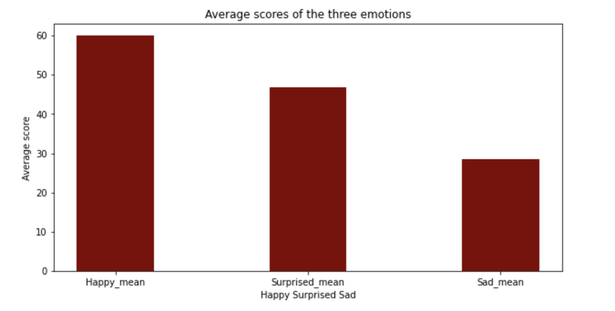

The graph shows that the emotion happy has the highest average score while sad has the lowest average score which means that the Rekognition may recognize Happy the best among the three emotions.

### Results

After testing the machine’s ability to detect emotions with different facial coverings, we realized that the machine’s ability to detect different facial expressions can vary. To test if the machine can detect the 4 emotions (happy, sad, surprised, angry) equally well, we decided to use t-tests to see if there is a significant difference. After the first round of testing each emotion with 3 other emotions (e.g. angry vs happy + sad + surprised; sad vs happy + angry + surprised), we concluded that the machine cannot distinguish the emotion of angry as well as the others by using the 95% confidence interval. For “angry”, the t-statistics is 1.47144, which is smaller than the t-statistics for 95% and degree of freedom 47 (in this sample, we have used all 48 pictures) which is 2.012. Therefore, it fails to reject the fact that the mean of “angry” and other emotions is equal, which means that the machine can’t distinguish the emotion “angry”. The t-statistics for “sad” is 2.077. The t-statistics for “happy” is 4.96784. The t-statistics for “surprised” is 5.0867.

To be more specific about our testing, we did another round of testing with each emotion (happy vs surprised, happy vs sad, sad vs surprised). The t-tests for the three combinations are all significant, which means that the machine can distinctively tell the emotion of happy, surprised, and sad. To further explore which emotions can be detected the best by the machine, we found the mean of the confidence score for three emotions and found out that “happy” has the highest confidence score, which means that it can be detected the best by the machine. Then, “happy” is followed by “surprised” and “sad”. In the end, we plan to proceed to do our regression with only 3 emotions (happy, sad, surprised) to make predictions.

## Predictions on Amazon Rekognition's Emotion Reading

Since from the last steps we have already found that the Amazon Rekognition is unable to detect "angry" as a distinct emotion, we then rule out the emotion from the four we choose. Then we try to make a prediction on how the confidence score of emotion will change if the target in the photo is wearing a mask or a pair of sunglasses.

We build two regression models to explore the correlation between the confidence score of emotion from the original photos and that from the photos with facial coverings.

### Regression Model 1

$Y_{mask} = \beta_0+\beta_1X_{origin}+u$

```
result1=smf.ols(formula = 'Mask ~ Origin', data = data8).fit()
result1.summary()
```

**OLS Regression Results**

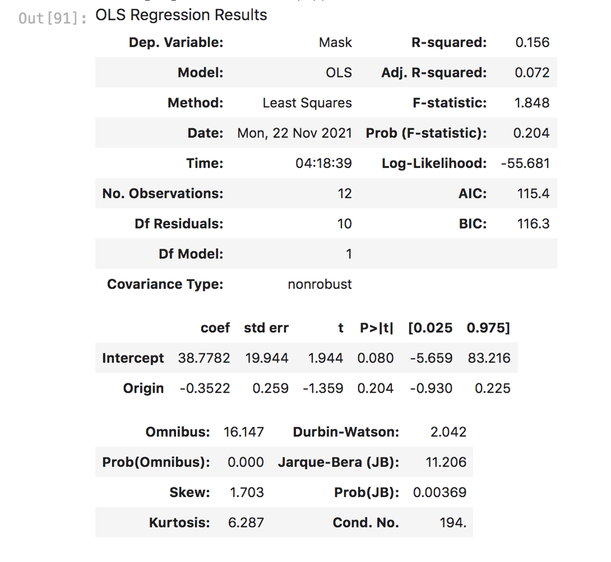

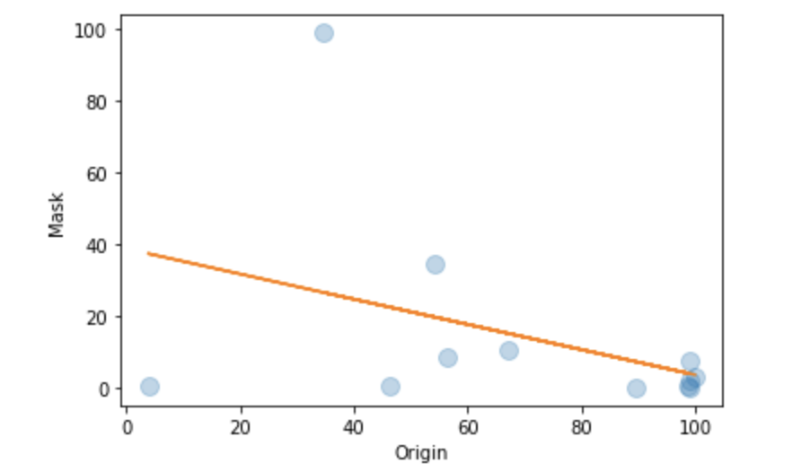

### Regression Model 2

$Y_{glasses} = \beta_0+\beta_1X_{origin}+u$

```
result2=smf.ols(formula = 'Sunglasses ~ Origin', data = data8).fit()
result2.summary()
```

**OLS Regression Results**

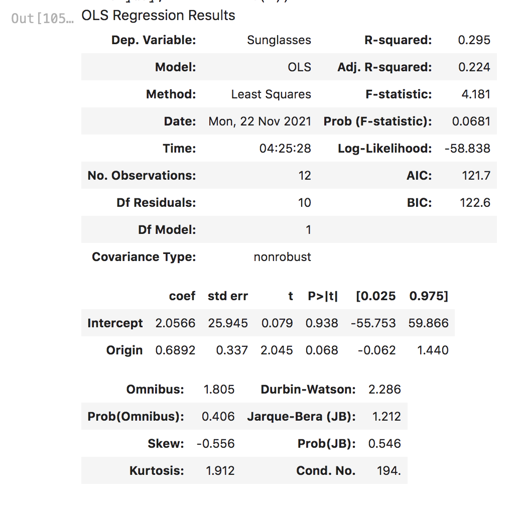

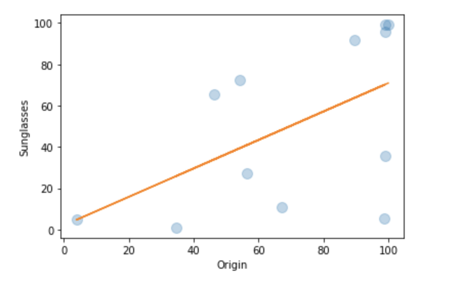

## Conclusions and Discussions

Based on our dataset and t testing results, we first find that Amazon Rekognition's emotion reading accuracy decreases when the targets on photos have put on facial coverings. In other words, if a person puts on a mask and takes a photo with a big smile on their face, Amazon Rekognition may not detect their emotions as happy as they should be without the mask. Since we already learned that human’s capability of reading emotions has become less accurate during the pandemic when everyone is wearing a mask, it would not be surprising to know the situation is similar here for Amazon Rekognition.

Since our dataset only concludes 48 pieces of data and there are only four targets in the photos, we believe further research should be conducted to see whether Amazon Rekognition has a stable ability to distinguish anger from other emotions. We suggest that a larger dataset should be incorporated with more people having different expressions of anger.

If you are interested in replicating our project, you can access our [Github](https://github.com/YukiLiu1029/Final-Project) to learn more about our dataset and the data extraction process.

## About Authors

**Yuki Liu**

- Senior Student at Emory University
- Major in Applied Mathematics & Statistics and Economics

**Matt He**

- Senior Student at Emory University
- Major in Applied Mathematics & Statistics and minor in Economics

**Evelyn Lin**

- Junior Student at Emory University
- Major in Applied Mathematics & Statistics and minor in Sociology

**Nancy Chen**

- Junior Student at Emory University
- Major in QSS and Economics